# Homework 1

Ella Marrero

4/5/2021

# Setup

First, we will load the data

```r
data = read.table("https://codowd.com/bigdata/hw1/Review_subset.csv",header=TRUE) # reviews
words = read.table("https://codowd.com/bigdata/hw1/words.csv") # words
words = words[,1]
doc_word = read.table("https://codowd.com/bigdata/hw1/word_freq.csv")
# word frequency (text-word pairing)
colnames(doc_word) = c("Review ID","Word ID","Times Word")
```

# Marginal Regression Screening

Then, we will create a matrix

```r
# Create a matrix of word presence
spm = matrix(0L,nrow = nrow(data),ncol=length(words))
for (index in 1:nrow(doc_word)) {
  i = doc_word[index,1]
  j = doc_word[index,2]
  spm[i,j] = doc_word[index,3]
}
colnames(spm) = words
```

## Simplify from Counts to presence

Create a dense dataframe of word presence – also going to be big. And a Y variable for use later.

```r
# define vars
P = as.data.frame(as.matrix(spm>0))
stars = data$Score

# runs marginal regressions
margreg = function(p){
    fit = lm(stars ~ P[[p]])
    sf = summary(fit)
    return(sf$coef[2,4]) # return p-value of coef
}
```

## Calculate Pvalues for every word

```r
ncores = detectCores()-1 # remove 1 core
# Make a cluster
cl = makeCluster(ncores)
# Export data to the cluster
clusterExport(cl,c("stars","P"))
# Run the regressions in parallel
pvals = parSapply(cl,1:length(words),margreg)
# Turn off cluster
stopCluster(cl)
```

### Tidy data

```r
# final product: vector of pvals, each of named by corresponding word
rm(data,doc_word,spm,P)
names(pvals) = words
```

# Homework Questions:

## Q1

First, we will plot the p-values.

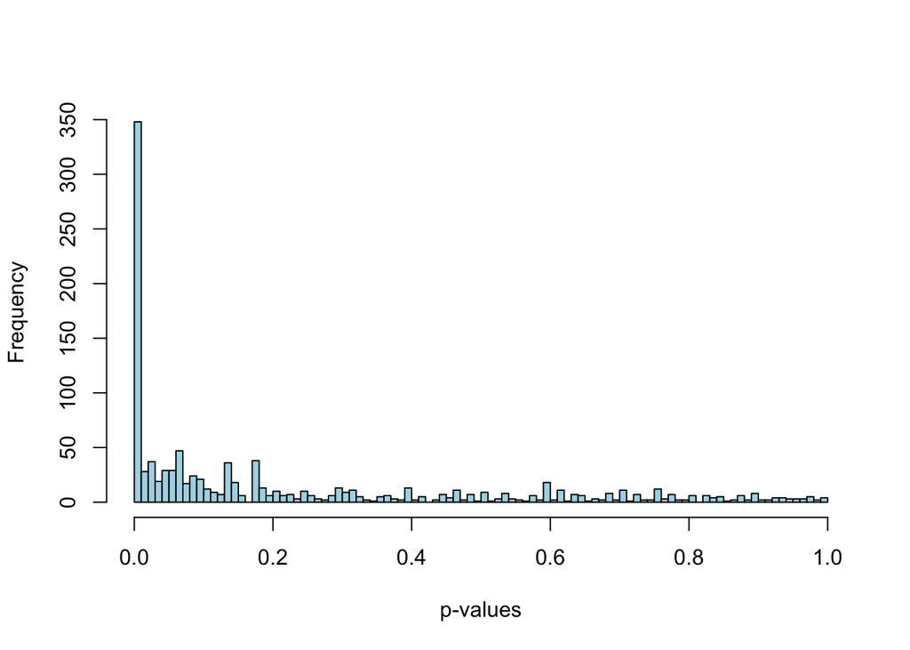

```r
hist(pvals, breaks=100,main='',xlab='p-values',
     col="lightblue")
```

The distribution is extremely right skewed, with a slight bimodal distribution (peaks at 0.01 and 0.1/0.2).

## Q2

From the p-value matrix we calculated, we can count the number of tests that are significant at the $\alpha=0.05$ and $0.01$?

```r
less_01 <- sum(pvals <= 0.01)
less_05 <- sum(pvals <= 0.05)
```

| Significance Level | Number of Tests |
| --- | --- |
| p < 0.01 | 348 |
| p < 0.05 | 461 |

## Q3

```r
fdr_cut_c <- function(pvals, q){
  pvals = pvals[!is.na(pvals)]
  K = length(pvals)
  k = rank(pvals, ties.method="min")
  alpha = max(pvals[ pvals<= (q*k/K) ])
  alpha
}

cutoff01 <- fdr_cut_c(pvals, 0.01)
```

[figure not shown]

```r
sig = factor(pvals<=cutoff01)
levels(sig) = c("lightgrey","maroon")

o = order(pvals)
K = length(pvals)

plot(pvals[o], col=sig[o], pch=20,
     ylab="p-values", xlab="tests ordered by p-value",
     main = 'FDR = 0.1%',log="xy")
```

## Q4

```r
num_disc <- sum(pvals<=cutoff01)
p_k <- 0.01*length(pvals)
```

## Q5

What are the 10 most significant words? Was ‘addictive’ significant’? Do these results make sense to you? (2 sentence max)

```r
o = order(pvals)
top10 <- pvals[o][1:10]
top10 <- cbind(rownames(top10), top10)
top10 <- cbind(word = rownames(top10), top10)
rownames(top10) <- 1:nrow(top10)
```

The 10 most significant words are:

| Word | Significance Level |
| --- | --- |
| not | 1.56877649474129e-165 |
| horrible | 3.01200734625169e-100 |
| great | 2.55699710061377e-74 |
| bad | 2.87655479660402e-58 |
| nasty | 1.12171960961462e-50 |
| disappointed | 2.14835360661274e-48 |
| new | 9.28553759065722e-46 |
| but | 2.70384028081536e-45 |
| same | 4.45427118194321e-40 |
| poor | 2.29980339355984e-39 |

## Q6

What are the advantages and disadvantages of our FDR ana;ysis? (4 sentence max)